# HW-lego-Tommy Yang

Tommy Yang

2/27/2022

```r
#remotes::install_github("rstudio-education/dsbox")
library(tidyverse)
library(dsbox)
```

Question 1. What are the three most common first names of purchasers?

```r
mostcom_fname<- lego_sales %>%
                 count(first_name, sort = TRUE) %>%
                 top_n(3)
mostcom_fname
```

```
## # A tibble: 3 × 2
##   first_name     n
##   <chr>      <int>
## 1 Jackson       13
## 2 Jacob         11
## 3 Joseph        11
```

#### In this sample, the first three common first names of purchasers are: Jackson,Jacob, Joseph.

Question 2. What are the three most common themes of Lego sets purchased?

```r
lego_sales %>%count(theme, sort = TRUE) %>%
                 top_n(3) # the top three purchased times of themes of Lego sets.
```

```
## # A tibble: 4 × 2
##   theme            n
##   <chr>        <int>
## 1 Star Wars       75
## 2 Nexo Knights    64
## 3 Gear            55
## 4 Mixels          55
```

```r
mostcom_theme<-lego_sales%>%
               group_by(theme)%>%
               summarise(tsales=sum(quantity))%>%
               arrange(desc(tsales))%>%
               top_n(3)
mostcom_theme
```

```
## # A tibble: 3 × 2
##   theme        tsales
##   <chr>         <dbl>
## 1 Star Wars       117
## 2 Nexo Knights     93
## 3 Mixels           83
```

#### In this sample, the first three common themes of Lego sets purchased are: Star Wars,Nexo Knights, Mixels.

Question 3. Among the most common theme of Lego sets purchased, what is the most common subtheme?

```r
mostcom_subtheme <- lego_sales %>%
                    filter(theme == as.character(mostcom_theme[1,1]))%>%
                    group_by(subtheme)%>%
                    summarise(ssales=sum(quantity))%>%
                    arrange(desc(ssales))#%>%
                    #top_n(3)

mostcom_subtheme
```

```
## # A tibble: 11 × 2
##    subtheme                  ssales
##    <chr>                      <dbl>
##  1 The Force Awakens             21
##  2 Buildable Figures             18
##  3 Episode V                     15
##  4 Battlefront                   12
##  5 MicroFighters                 11
##  6 Original Content              11
##  7 Episode III                   10
##  8 Seasonal                       8
##  9 Rebels                         7
## 10 Episode IV                     3
## 11 Ultimate Collector Series      1
```

```r
lego_sales%>% filter(subtheme %in% mostcom_subtheme$subtheme)
```

```
## # A tibble: 75 × 14
##    first_name last_name   age phone_number set_id number theme    subtheme  year
##    <chr>      <chr>     <dbl> <chr>         <dbl> <chr>  <chr>    <chr>    <dbl>
##  1 Bryanna    Welsh        19 <NA>          24797 75138  Star Wa… Episode…  2018
##  2 Amanda     Tronnier     45 317-555-7477  24959 75139  Star Wa… The For…  2018
##  3 Jacob      Nzabanita    31 339-555-2572  24793 75133  Star Wa… Battlef…  2018
##  4 Jacob      Nzabanita    31 339-555-2572  25920 75151  Star Wa… Episode…  2018
##  5 Riley      Ott          51 517-555-2093  24785 75126  Star Wa… MicroFi…  2018
##  6 Hector     Collins      20 340-555-2508  24781 75116  Star Wa… Buildab…  2018
##  7 Hector     Collins      20 340-555-2508  24627 75098  Star Wa… Ultimat…  2018
##  8 Cecilia    Mauro        50 <NA>          25921 75157  Star Wa… Rebels    2018
##  9 Connor     Fourzan      32 805-555-3065  24789 75130  Star Wa… MicroFi…  2018
## 10 Keno       Graves       51 209-555-6030  25898 75145  Star Wa… Origina…  2018
## # … with 65 more rows, and 5 more variables: name <chr>, pieces <dbl>,
## #   us_price <dbl>, image_url <chr>, quantity <dbl>
```

#### In this sample, among the most common themes of Lego sets purchased, the most common subtheme is: The Force Awakens.

Question 4. Create a new variable called age_group and group the ages into the following categories: “18 and under”, “19 - 25”, “26 - 35”, “36 - 50”, “51 and over”.

```r
 lego_sales$age_group <-  as.factor(ifelse(lego_sales$age <= 18, "18 and under",
                                    ifelse(lego_sales$age <= 25, "19-25",
                                    ifelse(lego_sales$age <= 35, "26-35",
                                    ifelse(lego_sales$age <= 50, "36-50",
                                    ifelse(lego_sales$age <= max(lego_sales$age),  "51 and over"))))))

lego_sales
```

```
## # A tibble: 620 × 15
##    first_name last_name      age phone_number set_id number theme subtheme  year
##    <chr>      <chr>        <dbl> <chr>         <dbl> <chr>  <chr> <chr>    <dbl>
##  1 Kimberly   Beckstead       24 216-555-2549  24701 76062  DC C… Mighty …  2018
##  2 Neel       Garvin          35 819-555-3189  25626 70595  Ninj… Rise of…  2018
##  3 Neel       Garvin          35 819-555-3189  24665 21031  Arch… <NA>      2018
##  4 Chelsea    Bouchard        41 <NA>          24695 31048  Crea… <NA>      2018
##  5 Chelsea    Bouchard        41 <NA>          25626 70595  Ninj… Rise of…  2018
##  6 Chelsea    Bouchard        41 <NA>          24721 10831  Duplo <NA>      2018
##  7 Bryanna    Welsh           19 <NA>          24797 75138  Star… Episode…  2018
##  8 Bryanna    Welsh           19 <NA>          24701 76062  DC C… Mighty …  2018
##  9 Caleb      Garcia-Wide…    37 907-555-9236  24730 41115  Frie… <NA>      2018
## 10 Caleb      Garcia-Wide…    37 907-555-9236  25611 21127  Mine… Minifig…  2018
## # … with 610 more rows, and 6 more variables: name <chr>, pieces <dbl>,
## #   us_price <dbl>, image_url <chr>, quantity <dbl>, age_group <fct>
```

Question 5. Which age group has purchased the highest number of Lego sets?

```r
group_purchase<-lego_sales %>%
                group_by(age_group)%>%
                summarise(group_sum=sum(quantity))%>%
                arrange(desc(group_sum))
group_purchase
```

```
## # A tibble: 5 × 2
##   age_group    group_sum
##   <fct>            <dbl>
## 1 36-50              313
## 2 26-35              267
## 3 19-25              174
## 4 51 and over         92
## 5 18 and under        45
```

#### In this sample, “36-50” years old group has purchased the highest number of Lego sets.

Question 6. Which age group has spent the most money on Legos?

```r
group_spend<-lego_sales %>%
                group_by(age_group)%>%
                summarise(group_sum=sum(quantity*us_price))%>%
                arrange(desc(group_sum))
group_spend
```

```
## # A tibble: 5 × 2
##   age_group    group_sum
##   <fct>            <dbl>
## 1 36-50            9533.
## 2 26-35            7576.
## 3 19-25            4939.
## 4 51 and over      2475.
## 5 18 and under      949.
```

#### In this sample, “36-50” years old group has purchased the highest number of Lego sets.

Question 7. Which Lego theme has made the most money for Lego?

```r
theme_sales<-lego_sales %>%
                group_by(theme)%>%
                summarise(sales=sum(quantity*us_price))%>%
                arrange(desc(sales))
theme_sales
```

```
## # A tibble: 25 × 2
##    theme        sales
##    <chr>        <dbl>
##  1 Star Wars    4448.
##  2 Ninjago      2279.
##  3 City         2211.
##  4 Nexo Knights 2209.
##  5 Minecraft    1550.
##  6 Gear         1533.
##  7 Friends      1279.
##  8 Duplo        1220.
##  9 Elves        1120.
## 10 Ghostbusters  880.
## # … with 15 more rows
```

#### In this sample,the theme of Star Warshas made the most money for Lego.

Question 8. Which area code has spent the most money on Legos? In the US the area code is the first 3 digits of a phone number.

```r
area_spend<-lego_sales%>%
              filter(!is.na(phone_number))%>%
              mutate(area_code = str_sub(phone_number,1,3))%>%
              group_by(area_code)%>%
              summarise(areasum=sum(quantity*us_price))%>%
              arrange(desc(areasum))
area_spend
```

```
## # A tibble: 156 × 2
##    area_code areasum
##    <chr>       <dbl>
##  1 956          720.
##  2 973          685.
##  3 567          550.
##  4 281          465.
##  5 316          438.
##  6 339          426.
##  7 209          350.
##  8 423          340.
##  9 778          335.
## 10 441          335.
## # … with 146 more rows
```

#### In this sample, the customers in area code 956 have spent the most money on Legos.

Question 9. Which price of Legos has the customer liked to purchase? Which pieces of Legos has the customer liked to purchase? What is the relationship between the pieces and price of the legos?

```r
lego_sales%>%count(us_price,sort = TRUE)
```

```
## # A tibble: 26 × 2
##    us_price     n
##       <dbl> <int>
##  1     9.99   108
##  2    20.0     79
##  3     4.99    69
##  4    30.0     68
##  5    15.0     46
##  6    25.0     39
##  7    50.0     37
##  8    40.0     30
##  9     5.99    23
## 10    13.0     23
## # … with 16 more rows
```

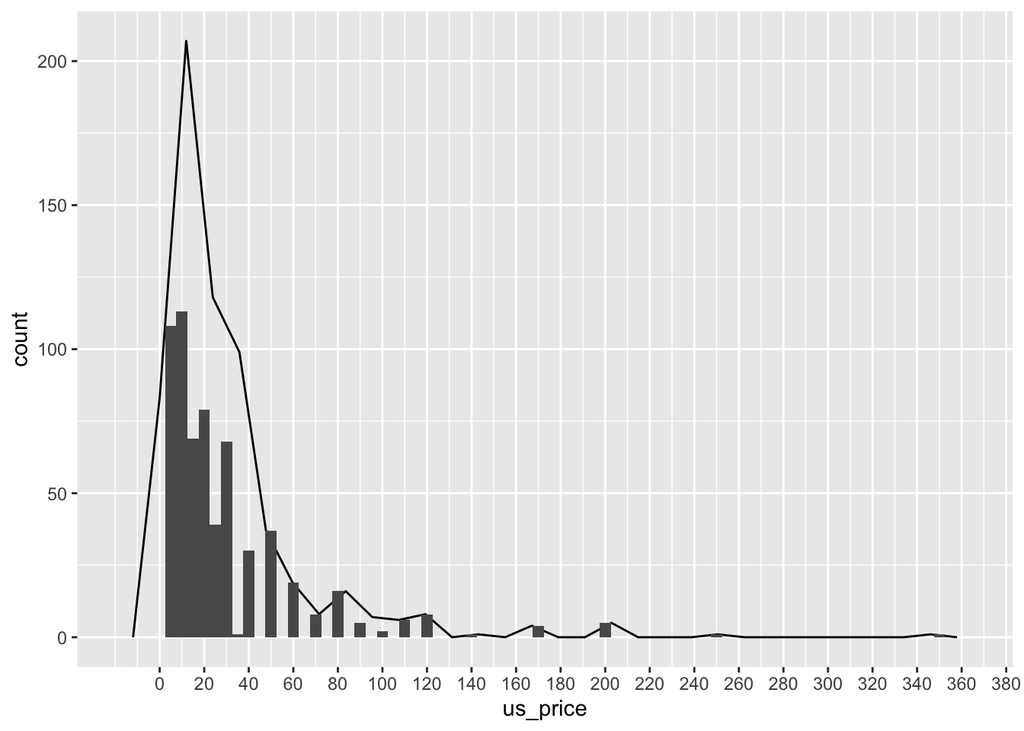

```r
lego_sales%>% ggplot(mapping = aes(x = us_price))+
    geom_freqpoly()+
    geom_histogram(binwidth = 5)+
    scale_x_continuous(breaks = seq(0, 400, by = 20))
```

```r
lego_sales%>%count(pieces,sort = TRUE)
```

```
## # A tibble: 172 × 2
##    pieces     n
##     <dbl> <int>
##  1     NA    69
##  2     70    16
##  3     63    14
##  4     64    14
##  5     98    13
##  6     40    10
##  7     76     8
##  8     80     8
##  9     92     8
## 10     87     7
## # … with 162 more rows
```

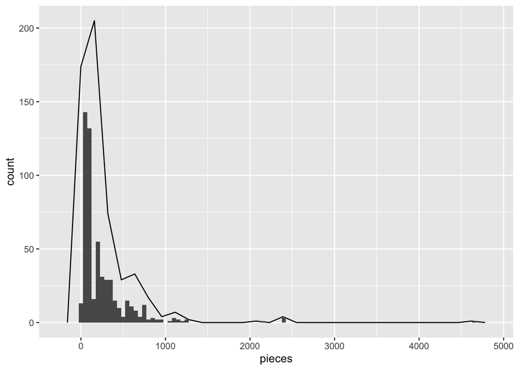

```r
lego_sales%>% ggplot(mapping = aes(x = pieces))+
    geom_freqpoly()+
    geom_histogram(binwidth = 50)
```

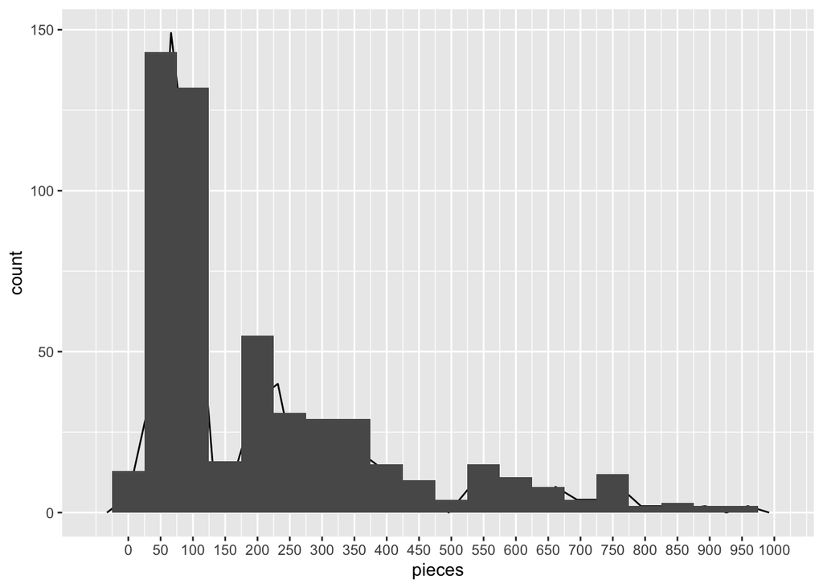

```r
    #(breaks = seq(0, 400, by = 20))
lego_sales%>%filter(pieces<1000) %>%ggplot(mapping = aes(x = pieces))+
    geom_freqpoly()+
    geom_histogram(binwidth = 50)+
    scale_x_continuous(breaks = seq(0, 1000, by = 50))
```

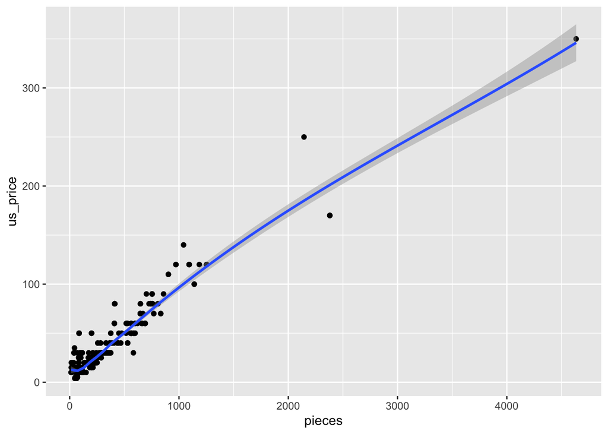

```r
ggplot(data = lego_sales, mapping = aes(x = pieces, y = us_price)) +
  geom_point()+
  geom_smooth()
```

### In this sample, roughly most of the custormers liked to purchase the legos with the price under $50 and the pieces under 400. The price of the lego has a approximate linear positive relationship with the pieces at a ratio of about 0.1.